# Homework 2

You Peng

2022-02-19

## Data Wrangling

#### A table summarize about the obesity level:

```
## # A tibble: 4 x 4
##   obesity_level min_BMI max_BMI count
##   <chr>           <dbl>   <dbl> <int>
## 1 normal           14.0    22.0   975
## 2 obese            24.0    41.3   103
## 3 overweight       22.0    24.0    87
## 4 underweight      11.3    14.0    35
```

We can see that most children had a normal obesity level. And only 35 children are in underweight obesity level, which is the smallest level. We can also check the min BMI and max BMI to see that levels are made correctly.

#### Create new variable smoke_gas_exposure:

```r
df <- df %>% mutate(smoke_gas_exposure = as.factor(interaction(smoke, gasstove)))
```

Note that the first element in smoke_gas_exposure corresponds to the indicator for “second hand smoke”, the second element corresponds to the indicator for gas exposure. For example, for pair (smoke, gas stove) being (0, 0), smoke_gas_exposure will take value 0.0; when it’s (0, 1), smoke_gas_exposure will take value 0.1.

#### Summary of “Forced expiratory volume in 1 second (ml)” and asthma indicator by town:

```
## # A tibble: 12 x 5
##    townname      Mean_of_FEV Sd_of_FEV Mean_of_asthma Sd_of_asthma
##    <fct>               <dbl>     <dbl>          <dbl>        <dbl>
##  1 Alpine              2087.      291.           0.11        0.314
##  2 Atascadero          2076.      324.           0.25        0.435
##  3 Lake Elsinore       2039.      304.           0.12        0.327
##  4 Lake Gregory        2085.      320.           0.15        0.359
##  5 Lancaster           2003.      317.           0.16        0.368
##  6 Lompoc              2034.      351.           0.11        0.314
##  7 Long Beach          1986.      319.           0.13        0.338
##  8 Mira Loma           1985.      325.           0.15        0.359
##  9 Riverside           1990.      278.           0.11        0.314
## 10 San Dimas           2027.      319.           0.17        0.378
## 11 Santa Maria         2026.      312.           0.13        0.338
## 12 Upland              2024.      343.           0.12        0.327
```

#### Summary of “Forced expiratory volume in 1 second (ml)” and asthma indicator by sex:

```
## # A tibble: 2 x 5
##    male Mean_of_FEV Sd_of_FEV Mean_of_asthma Sd_of_asthma
##   <int>       <dbl>     <dbl>          <dbl>        <dbl>
## 1     0       1959.      312.          0.118        0.323
## 2     1       2104.      308.          0.168        0.374
```

#### Summary of “Forced expiratory volume in 1 second (ml)” and asthma indicator by obesity level:

```
## # A tibble: 4 x 5
##   obesity_level Mean_of_FEV Sd_of_FEV Mean_of_asthma Sd_of_asthma
##   <chr>               <dbl>     <dbl>          <dbl>        <dbl>
## 1 normal              2000.      295.         0.136         0.343
## 2 obese               2266.      325.         0.204         0.405
## 3 overweight          2224.      317.         0.161         0.370
## 4 underweight         1698.      303.         0.0857        0.284
```

#### Summary of “Forced expiratory volume in 1 second (ml)” and asthma indicator by smoke_gas_exposture:

```
## # A tibble: 4 x 5
##   smoke_gas_exposure Mean_of_FEV Sd_of_FEV Mean_of_asthma Sd_of_asthma
##   <fct>                    <dbl>     <dbl>          <dbl>        <dbl>
## 1 0.0                      2057.      329.          0.142        0.349
## 2 1.0                      2056.      296.          0.167        0.378
## 3 0.1                      2023.      319.          0.145        0.353
## 4 1.1                      2025.      301.          0.123        0.330
```

## Looking at the data

### EDA

```r
dim(df)
```

```
## [1] 1200   51
```

The dataset has 1200 observations, which represent 1200 children. It has 51 variables, which includes both health characteristics of children and air quality measurements at the community level.

#### Take a look at the first 6 rows and last 6 rows of the dataset:

```
## # A tibble: 6 x 51
## # Groups:   male, hispanic [3]
##   townname   sid  male race  hispanic agepft height weight   bmi asthma
##   <fct>    <int> <int> <chr>    <int>  <dbl>  <dbl>  <dbl> <dbl>  <dbl>
## 1 Alpine     841     1 W            1  10.5     150     78  15.8      0
## 2 Alpine     835     0 W            0  10.1     143     69  15.3      0
## 3 Alpine     838     0 O            1   9.49    133     62  15.9      0
## 4 Alpine     840     0 W            0   9.97    146     78  16.6      0
## 5 Alpine     865     0 W            0  10.0     162    140  24.2      1
## 6 Alpine     867     0 W            1   9.96    141     94  21.5      0
## # ... with 41 more variables: active_asthma <int>, father_asthma <dbl>,
## #   mother_asthma <dbl>, wheeze <dbl>, hayfever <dbl>, allergy <dbl>,
## #   educ_parent <dbl>, smoke <dbl>, pets <int>, gasstove <dbl>, fev <dbl>,
## #   fvc <dbl>, mmef <dbl>, pm25_mass <dbl>, pm25_so4 <dbl>, pm25_no3 <dbl>,
## #   pm25_nh4 <dbl>, pm25_oc <dbl>, pm25_ec <dbl>, pm25_om <dbl>, pm10_oc <dbl>,
## #   pm10_ec <dbl>, pm10_tc <dbl>, formic <dbl>, acetic <dbl>, hcl <dbl>,
## #   hno3 <dbl>, o3_max <dbl>, o3106 <dbl>, o3_24 <dbl>, no2 <dbl>, ...
```

```
## # A tibble: 6 x 51
## # Groups:   male, hispanic [3]
##   townname   sid  male race  hispanic agepft height weight   bmi asthma
##   <fct>    <int> <int> <chr>    <int>  <dbl>  <dbl>  <dbl> <dbl>  <dbl>
## 1 Upland    1866     0 O            1   9.81   139    60    14.1      0
## 2 Upland    1867     0 M            1   9.62   140    71    16.5      0
## 3 Upland    2033     0 M            0  10.1    130    67    18.0      0
## 4 Upland    2031     1 W            0   9.80   135    83    20.7      0
## 5 Upland    2032     1 W            0   9.55   137    59    14.3      0
## 6 Upland    2053     0 W            0   9.85   139.   77.4  18.1      0
## # ... with 41 more variables: active_asthma <int>, father_asthma <dbl>,
## #   mother_asthma <dbl>, wheeze <dbl>, hayfever <dbl>, allergy <dbl>,
## #   educ_parent <dbl>, smoke <dbl>, pets <int>, gasstove <dbl>, fev <dbl>,
## #   fvc <dbl>, mmef <dbl>, pm25_mass <dbl>, pm25_so4 <dbl>, pm25_no3 <dbl>,
## #   pm25_nh4 <dbl>, pm25_oc <dbl>, pm25_ec <dbl>, pm25_om <dbl>, pm10_oc <dbl>,
## #   pm10_ec <dbl>, pm10_tc <dbl>, formic <dbl>, acetic <dbl>, hcl <dbl>,
## #   hno3 <dbl>, o3_max <dbl>, o3106 <dbl>, o3_24 <dbl>, no2 <dbl>, ...
```

#### Take a look at the BMIs of children overall:

```
##    Min. 1st Qu.  Median    Mean 3rd Qu.    Max.
##   11.30   15.96   17.81   18.50   19.99   41.27
```

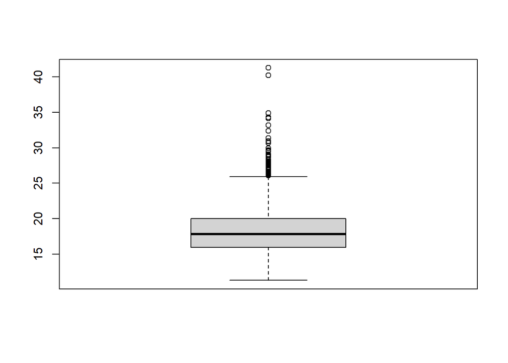

The mean BMI over all children is 18.5. We can see that there are some outliers had their BMI far higher than the mean of BMI overall. Those children might also have their forced expiratory volumes deviates from the general mean. Meanwhile, there aren’t any outliers had their BMI below the first quantile.

#### Take a look at the forced expiratory volumes of children overall:

```
##    Min. 1st Qu.  Median    Mean 3rd Qu.    Max.
##   984.8  1827.6  2016.4  2030.1  2223.6  3323.7
```

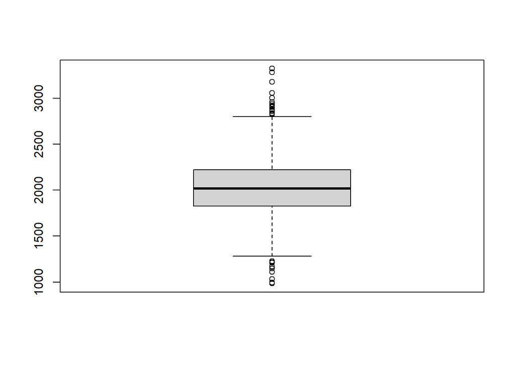

The mean FEV over all children is 2030. Unlike the situation in BMI, the outliers far above the mean or below the mean are about the same number.

#### Take a look at the smoke and gas exposure of children overall:

```
## # A tibble: 4 x 2
##   smoke_gas_exposure count
##   <fct>              <int>
## 1 0.0                  219
## 2 1.0                   36
## 3 0.1                  791
## 4 1.1                  154
```

Note that most of the children are exposed to gas and not second hand smokes.

#### Take a look at the PM2.5 mass of towns overall:

```
##    Min. 1st Qu.  Median    Mean 3rd Qu.    Max.
##   5.960   7.615  10.545  14.362  20.988  29.970
```

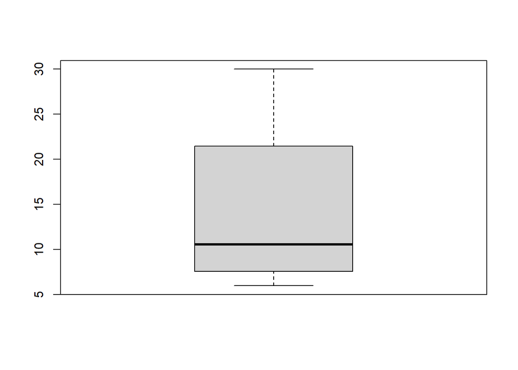

The mean PM2.5 mass over all towns is 14.362. There are no outliers in PM2.5 mass’s distribution. However, we can see that the distribution is right skewed, since the mean is larger than median.

### Visualization

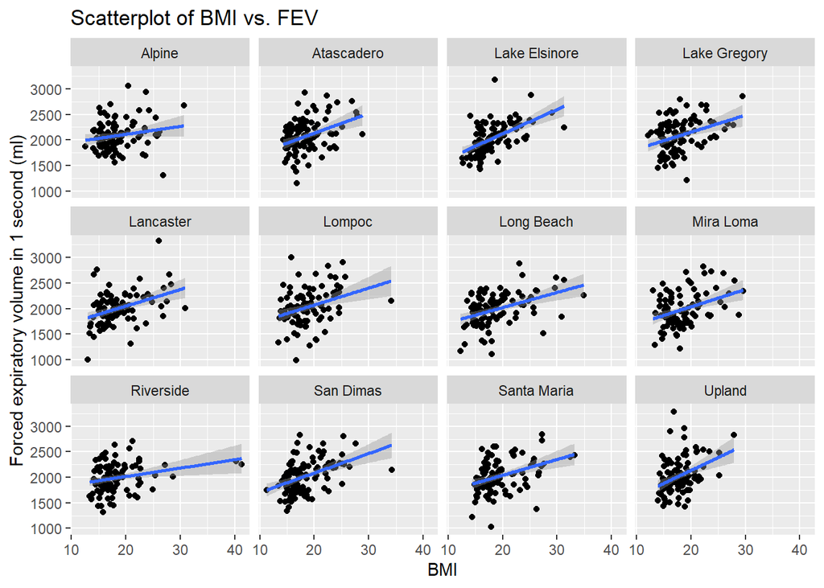

From scatterplots of BMI versus forced expiratory volume, we can see a positive linear relationship between FEV and BMI, where FEV will be higher when BMI is higher in general. This positive pattern agrees on all 12 towns. From all these 12 towns, Upland tends to have the most steep slope, which means that children whose BMI is larger in this town tends to have a more significant increase in FEV. Alpine and Riverside tends to have similar and the most flat slope, which means that children whose BMI is larger in these two towns tends to have a less significant increase in FEV. It’s also notable that children in most towns had their BMI between 12 and 35, except that two children in Riverside has their BMI over 40.

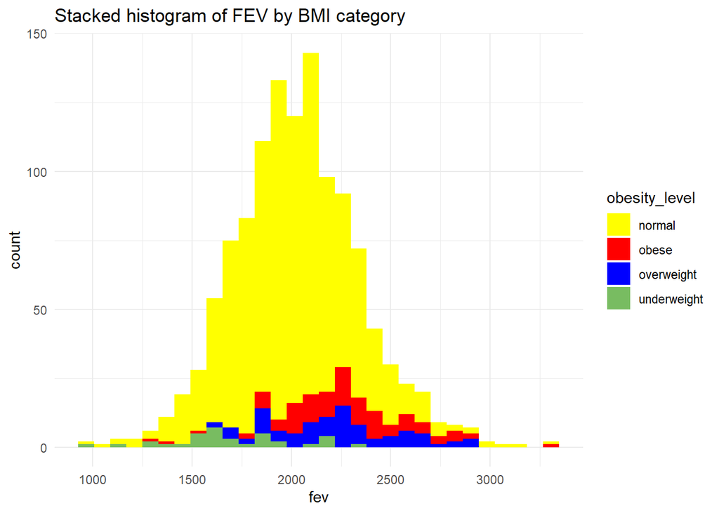

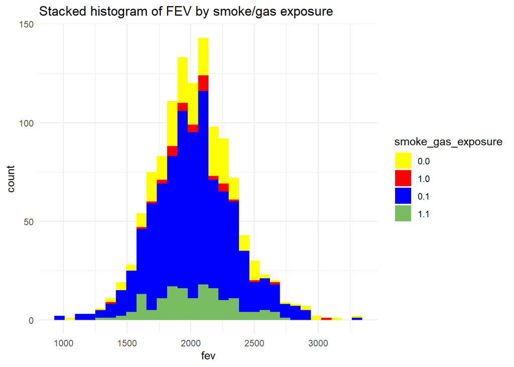

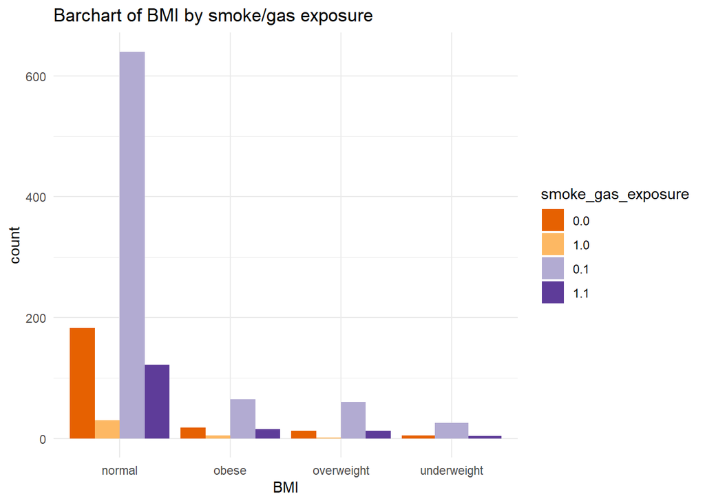

From the bar chart, we can see that most of children are only exposed to gas and not second hand smoke, no matter which obesity level they are. It’s also clear that there are no children in underweight level who have been exposed only to second hand smoke. Lastly, we can also see that the distribution of four categories of smoke/gas exposure looks very similar in obese group and overweight group.

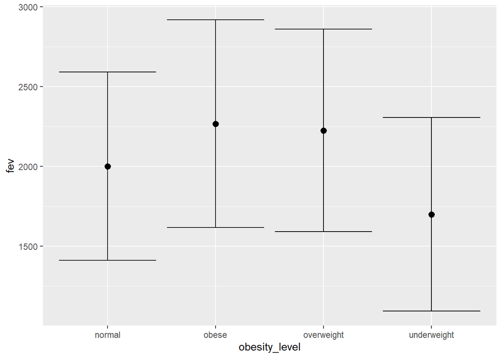

```r
df %>% ggplot() + aes(x=obesity_level, y=fev) + stat_summary(fun.data = "mean_sdl", geom = "errorbar") + stat_summary(fun.data = "mean_sdl")
```

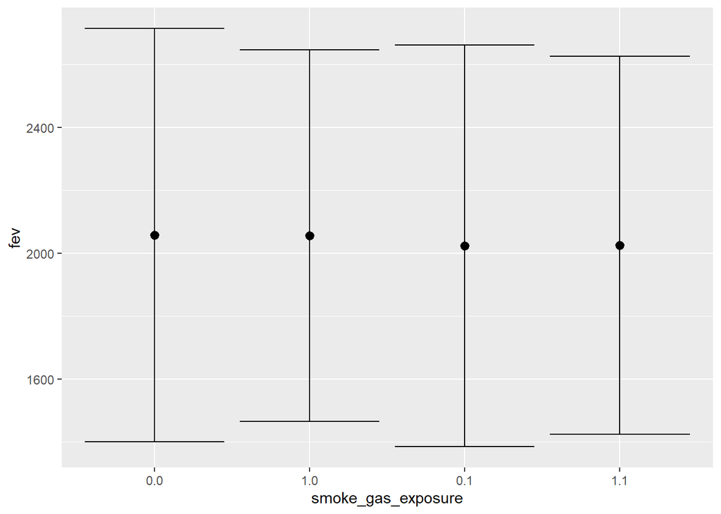

```r
df %>% ggplot() + aes(x=smoke_gas_exposure, y=fev) + stat_summary(fun.data = "mean_sdl", geom = "errorbar") + stat_summary(fun.data = "mean_sdl")
```

From the max-min plot on obesity level and FEV, we can see that children in obese level has a mean of FEV being around 2250, which is the highest mean of FEV among all other groups. The second place is overweight group, with a mean of FEV being around 2250 as well. The children in normal group has their mean of FEV being 2000, and the children in underweight group has their mean of FEV being 1700. This observation indicates that children with higher BMI are more likely to have higher FEV in general. This conclusion is same to the conclusion draw from the stacked histogram.

From the max-min plot on smoke/gas exposure and FEV, we can see that children who haven’t been exposed to gas had their mean of FEV a little bit higher than children who have been exposed to gas. However, the difference in means are not significant. Moreover, children who haven’t been exposed to second hand smoke had their max-min difference of FEV a little bit larger than children who have been exposed to second hand smoke. Overall speaking, there are not much difference on FEV in different categories of smoke/gas exposure. This conclusion is same to the conclusion draw from the stacked histogram.

[interactive chart not shown]

From the map we generates, we can see that towns around Los Angeles tend to have higher PM2.5 concentration. Especially for towns near River side, they had the most PM2.5 mass. For other towns far away from Los Angeles, such as those located around Santa Maria, they had lighter PM2.5 concentration. Such situation may be explained by that Los Angeles is close to the Pacific Ocean, so that the wind comes from the sea helps to reduce the concentration of PM2.5 at Los Angeles. And the PM2.5 pollution were brought by wind until they fall to the Riverside, which makes Riverside to have the worst PM2.5 concentration.

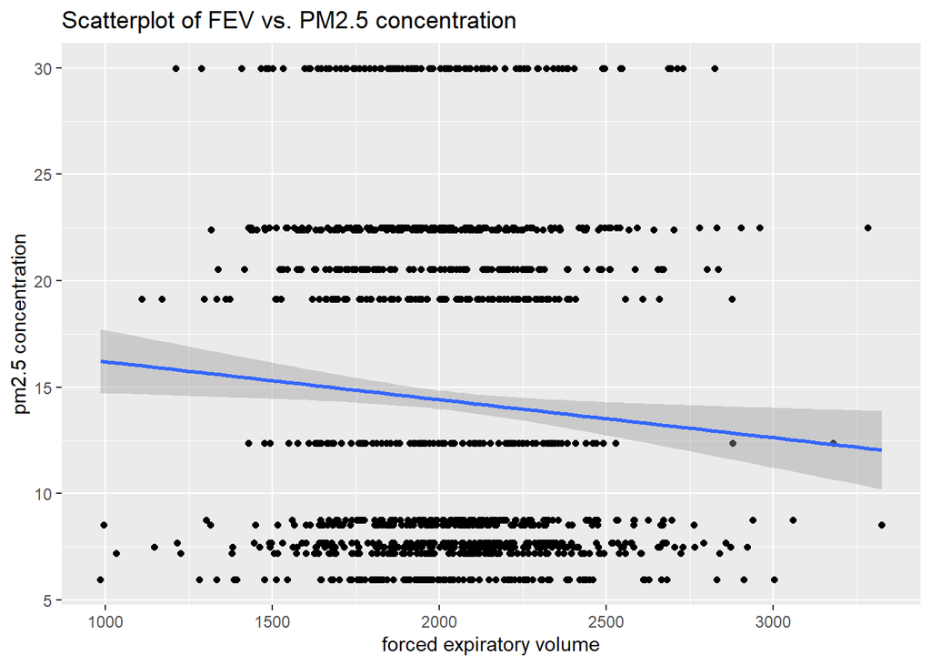

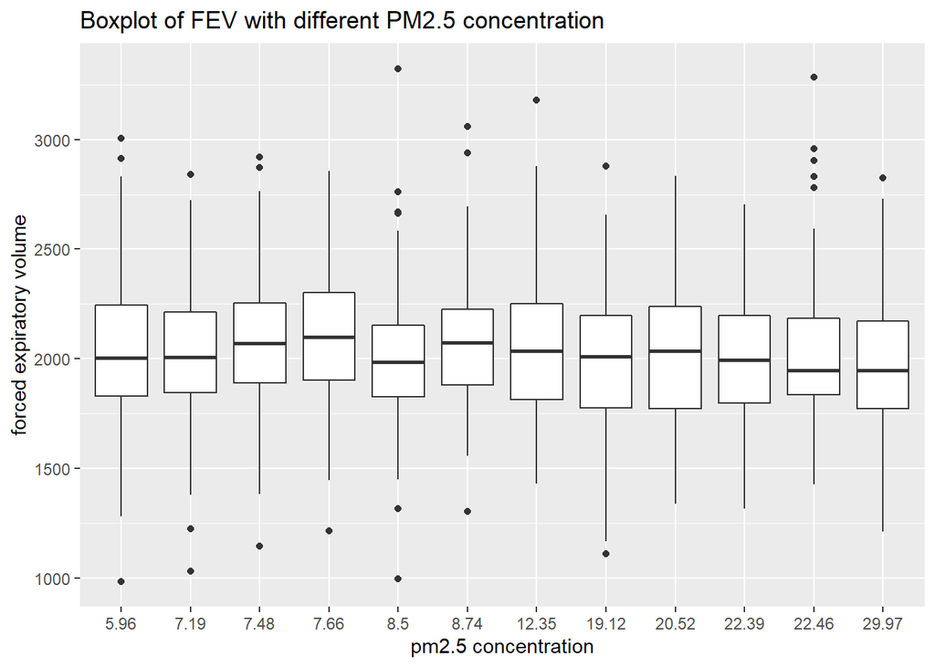

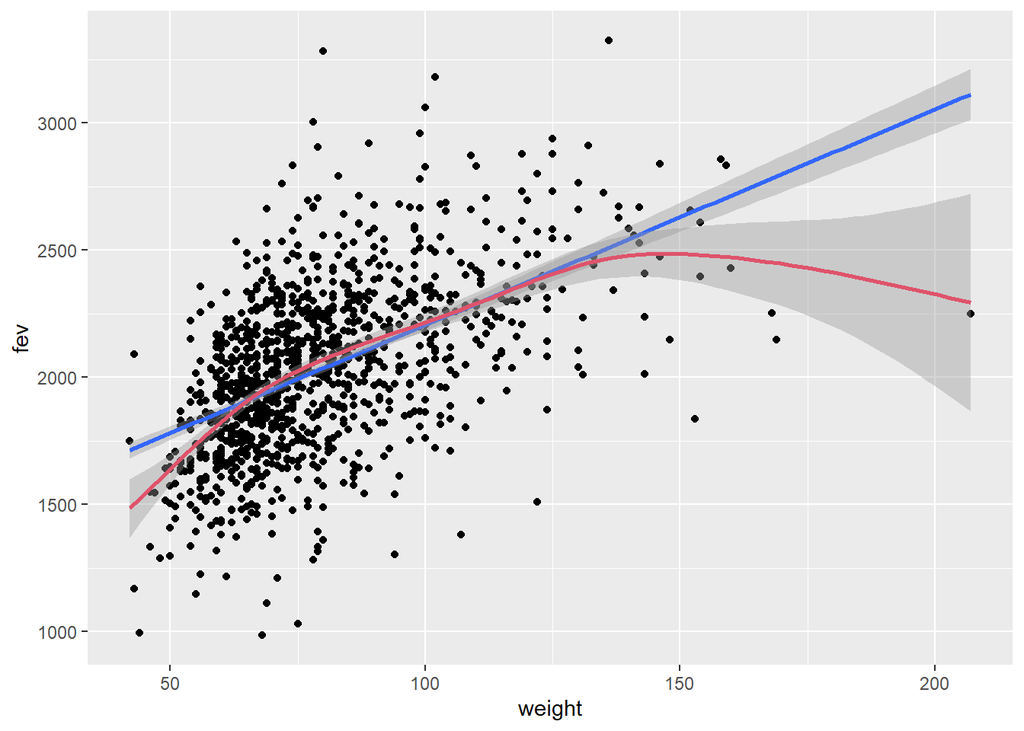

```r
ggplot(df, aes(x=weight, y=fev)) + geom_point() + geom_smooth(method="lm") + geom_smooth(method = "gam", col=2, formula = y ~ s(x, bs="cr", k=20))
```

From the plot, we can see the plot of linear association and non-linear association passing through the cluster of points. Most part of the non-linear regression line are below the linear regression line, while it’s higher than the linear line when weight is between 65 to 100. Moreover, if we assume the gam regression line is a quadratic curve, then it is concave. Meanwhile, the linear line has a positive slope. Lastly, it notable that these two regression lines are not adjusted for age, sex, and race, which means that the coefficient of these lines may differ from the coefficient provided by the model.

```r
library(mgcv)
lm_mod <- lm(fev ~ weight+agepft+as.factor(male)+as.factor(race), data=df)
summary(lm_mod)
```

```
##
## Call:
## lm(formula = fev ~ weight + agepft + as.factor(male) + as.factor(race),
##     data = df)
##
## Residuals:
##      Min       1Q   Median       3Q      Max
## -1005.07  -154.59   -11.85   159.01  1172.53
##
## Coefficients:
##                  Estimate Std. Error t value Pr(>|t|)
## (Intercept)      463.4347   181.0804   2.559 0.010612 *
## weight             8.1816     0.3755  21.791  < 2e-16 ***
## agepft            75.1951    18.0579   4.164 3.35e-05 ***
## as.factor(male)1 113.5737    14.9325   7.606 5.72e-14 ***
## as.factor(race)B -89.3838    49.4976  -1.806 0.071199 .
## as.factor(race)D  57.9595    75.1508   0.771 0.440716
## as.factor(race)M 104.7492    42.1157   2.487 0.013012 *
## as.factor(race)O 128.5796    39.0348   3.294 0.001017 **
## as.factor(race)W 140.6282    37.2050   3.780 0.000165 ***
## ---
## Signif. codes:  0 '***' 0.001 '**' 0.01 '*' 0.05 '.' 0.1 ' ' 1
##
## Residual standard error: 255.4 on 1191 degrees of freedom
## Multiple R-squared:  0.3593, Adjusted R-squared:  0.355
## F-statistic:  83.5 on 8 and 1191 DF,  p-value: < 2.2e-16
```

For this linear model, it’s clear that the FEV is expected to be 463.43 if given all other predictors as 0. We can also see that the FEV is expected to increase 8.18 given a one-unit shift in the weight while holding other variables in the model constant. From the p value of weight, we can see that the weight is a significant linear predictor in the model. The R-squared is 0.3593, which means that the linear model explains 35.9% of variance in FEV. The adjusted R^2 is 0.355, which is not large.

```r
gam_mod <- gam(fev ~ s(weight, bs="cr", k=20)+agepft+as.factor(male)+as.factor(race), data=df)
summary(gam_mod)
```

```
##
## Family: gaussian
## Link function: identity
##
## Formula:
## fev ~ s(weight, bs = "cr", k = 20) + agepft + as.factor(male) +
##     as.factor(race)
##
## Parametric coefficients:
##                  Estimate Std. Error t value Pr(>|t|)
## (Intercept)       1173.83     178.28   6.584 6.86e-11 ***
## agepft              70.32      17.70   3.973 7.54e-05 ***
## as.factor(male)1   113.10      14.64   7.723 2.41e-14 ***
## as.factor(race)B  -111.75      48.60  -2.299 0.021667 *
## as.factor(race)D    48.72      73.62   0.662 0.508268
## as.factor(race)M   102.26      41.29   2.477 0.013402 *
## as.factor(race)O   114.21      38.30   2.982 0.002925 **
## as.factor(race)W   125.97      36.50   3.451 0.000578 ***
## ---
## Signif. codes:  0 '***' 0.001 '**' 0.01 '*' 0.05 '.' 0.1 ' ' 1
##
## Approximate significance of smooth terms:
##             edf Ref.df     F p-value
## s(weight) 4.907  6.193 88.22  <2e-16 ***
## ---
## Signif. codes:  0 '***' 0.001 '**' 0.01 '*' 0.05 '.' 0.1 ' ' 1
##
## R-sq.(adj) =  0.382   Deviance explained = 38.8%
## GCV =  63177  Scale est. = 62498     n = 1200
```

For this gam model, the FEV is expected to be 1173.83 if given all other predictors as 0. We can also see that the p value of smoothed weight is smaller than 0.001, which means the smoothed weight is a significant predictor in the model. We can also see that age and sex are significant, but that’s not what we are interested in. It’s notable that this non-linear model explains 38.8% of variance in FEV, which is larger than the linear model. The adjusted R^2 is 0.382, which means that this non-linear model fit the data better after considering the degreee of freedom in the model.